# Pot Survey – April 2023

April 10 - 13, 2023 *F/V Integrity* West Ocean City, MD

Author

Mike O’Brien (UMCES)

[interactive chart not shown]

## Packing list

🔲 Large cooler

🔲 Sampling bags

🔲 Data sheets/clipboard

🔲 >2 fish pots

🔲 Two kill buckets

🔲 GPS

🔲 MS222

🔲 Measuring board

🔲 Weight bucket with scales

🔲 2 fish totes

## Participants

### April 10-11

- Dave Secor: 301-481-5053
- Mike O’Brien: 267-970-1973
- Lauren Rodriguez: 586-904-1264

### April 12-13

- Dave Secor
- Mike O’Brien
- Lauren Rodriguez
- Capt. Kerry Harrington
- *Integrity* mate

## Schedule

### 10 April

Scientific crew (DHS, MOB, LR)

- 0800 - 0900 Pack CBL truck (2013 Silverado) at Solomons, MD.
- 0900 - 1015 Drive to Harry S Truman Park and Ride
  - 200 Harry S. Truman Pkwy, Annapolis, MD 21401
- 1015 - 1230 Drive to Sea Born, Inc.
  - 12906 Sunset Ave, Ocean City, MD 21842
- 1230 - 1330 Say “hello” to Harringtons and Co.
- 1330 - 1340 Drive to MD Coastal Bays Program office
  - 8219 Stephen Decatur Hwy, Berlin, MD 21811
- 1340 - 1800 Assess, correct, and re-rig equipment.
- 1800 Return to West Ocean City. Check into Microtel.
  - 12536 Ocean Gateway, Ocean City, MD 21842

### 11 April

Scientific & Sea Born crew (KH, mate)

- 1000 - 1020 Drive to MD Coastal Bays Program office.
- 1020 - 1040 Load pots and two rope drums onto trailer.
- 1040 - 1050 Drive to Sea Born, Inc.
- 1050 - 1120 Unload pots. Captain/mate begin loading pots onto vessel.
- 1120 - 1330 Sci. crew drive to MD Coastal Bays Program. Repeat pot loading/return/unloading.
- 1330 - 1400 Drop trailer off at MDCBP. Return to W Ocean City.
- 1400 - 1600 Finish rigging ground line.

### April 12

Scientific & Sea Born crew

- 04:00 Meet at *F/V Integrity*
- 04:30 Depart OCMD for **C2304-1**
- **38 11.5997, -74 43.9367**
- 06:55 Arrive **C2304-1**. Deploy pots.
- 07:05 Finish deploying pots. Depart for **C2304-2**
- **38 14.2392, -74 36.9743**
- 07:55 Arrive **C2304-2**. Deploy pots.
- 08:05 Finish deploying pots. Depart for **M10**
- **38 18.1605, -74 40.6845**
- 08:45 Arrive **M10**. Deploy pots.
- 08:55 Finish deploying pots. Depart for **M09**
- **38 19.1724, -74 40.5209**
- 09:05 Arrive **M09**. Deploy pots.
- 09:15 Finish deploying pots. Depart for **L11**
- **38 17.1511, -74 41.8255**
- 09:35 Arrive **L11**. Deploy pots.
- 09:45 Finish deploying pots. Depart for **K11**
- **38 17.1534, -74 42.8029**
- 09:55 Arrive **K11**. Deploy pots.
- 10:05 Finish deploying pots. Depart for **OCMD**
- 12:25 Arrive **OCMD**

Pick up dry ice from Harris Teeter

- 31221 Americana Pkwy, Selbyville, DE 19975

### April 13

Scientific & Sea Born crew

- 04:00 Meet at *F/V Integrity*
- 04:30 Depart OCMD for **C2304-1**
- 06:55 Arrive **C2304-1**. Deploy pots.
- 07:10 Finish deploying pots. Depart for **C2304-2**
- 08:00 Arrive **C2304-2**. Deploy pots.
- 08:15 Finish deploying pots. Depart for **M10**
- 08:55 Arrive **M10**. Deploy pots.
- 09:10 Finish deploying pots. Depart for **M09**
- 09:20 Arrive **M09**. Deploy pots.
- 09:35 Finish deploying pots. Depart for **L11**
- 09:55 Arrive **L11**. Deploy pots.
- 10:10 Finish deploying pots. Depart for **K11**
- 10:20 Arrive **K11**. Deploy pots.
- 10:35 Finish deploying pots. Depart for **OCMD**
- 12:55 Arrive **OCMD**
- 13:15 Pick up trailer from MD Coastal Bays Program
- 13:30 Remove pots from F/V Integrity, load onto trailer. Unload at MD Coastal Bays program. Repeat as needed.

14:55 Scientific crew drive back to Solomons, MD

## Distances

Distance, nautical miles

|  | OCMD | C2304-1 | C2304-2 | L11 | M10 | M09 | K11 |
| --- | --- | --- | --- | --- | --- | --- | --- |
| OCMD | 0.00 | 19.26 | 23.59 | 19.30 | 20.09 | 20.16 | 18.54 |
| C2304-1 | 19.26 | 0.00 | 6.08 | 5.80 | 7.05 | 8.04 | 5.63 |
| C2304-2 | 23.59 | 6.08 | 0.00 | 4.80 | 4.89 | 5.67 | 5.43 |
| L11 | 19.30 | 5.80 | 4.80 | 0.00 | 1.35 | 2.27 | 0.77 |
| M10 | 20.09 | 7.05 | 4.89 | 1.35 | 0.00 | 1.02 | 1.95 |
| M09 | 20.16 | 8.04 | 5.67 | 2.27 | 1.02 | 0.00 | 2.70 |
| K11 | 18.54 | 5.63 | 5.43 | 0.77 | 1.95 | 2.70 | 0.00 |

Distance, time at 8 kts

|  | OCMD | C2304-1 | C2304-2 | L11 | M10 | M09 | K11 |
| --- | --- | --- | --- | --- | --- | --- | --- |
| OCMD | - | 02 h 25 m | 03 h 00 m | 02 h 25 m | 02 h 35 m | 02 h 35 m | 02 h 20 m |
| C2304-1 | 02 h 25 m | - | 00 h 50 m | 00 h 45 m | 00 h 55 m | 01 h 05 m | 00 h 45 m |
| C2304-2 | 03 h 00 m | 00 h 50 m | - | 00 h 40 m | 00 h 40 m | 00 h 45 m | 00 h 45 m |
| L11 | 02 h 25 m | 00 h 45 m | 00 h 40 m | - | 00 h 15 m | 00 h 20 m | 00 h 10 m |
| M10 | 02 h 35 m | 00 h 55 m | 00 h 40 m | 00 h 15 m | - | 00 h 10 m | 00 h 15 m |
| M09 | 02 h 35 m | 01 h 05 m | 00 h 45 m | 00 h 20 m | 00 h 10 m | - | 00 h 25 m |
| K11 | 02 h 20 m | 00 h 45 m | 00 h 45 m | 00 h 10 m | 00 h 15 m | 00 h 25 m | - |

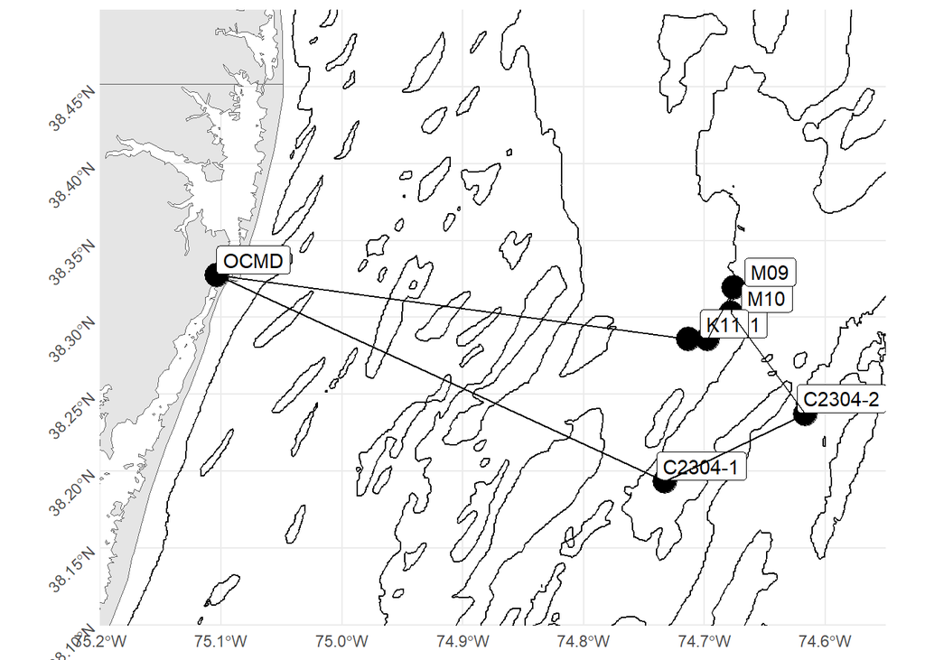